# Lab 4: Data pipelines & the grammar of graphics (gg)

## 2.3 Research questions

> **Research question**: Is there a relationship between petal length and petal width? - Yes, linear model.

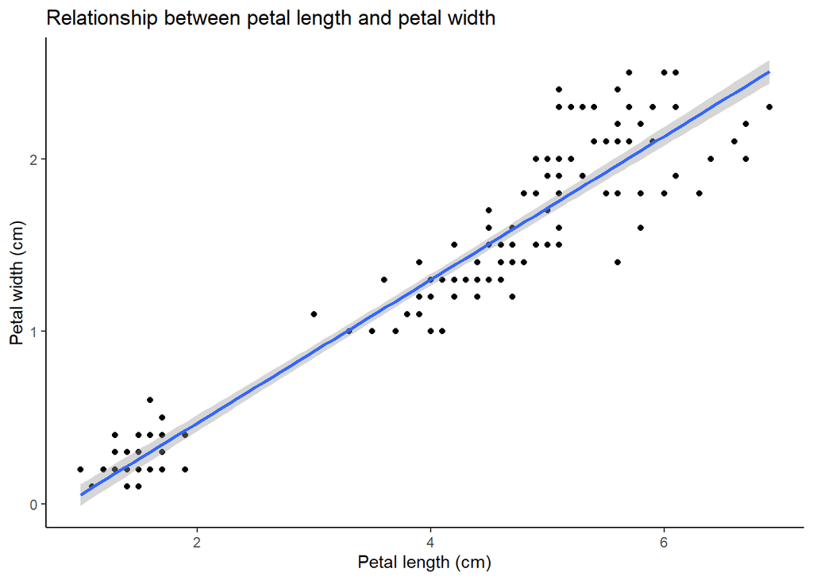

```r
iris %>%
  select(Petal.Length, Petal.Width) %>% # This can be ignored, but why keep?
  # If the data was pre-processed, like drop_na(), not selecting can make all categories drop NAs. However, this can be helpful for our analysis of targeted categories.
  drop_na() %>%

  ggplot(aes(Petal.Length, Petal.Width)) +
  geom_point() +
  geom_smooth(method = "lm") + # generate linear regression line
  xlab ("Petal length (cm)") +
  ylab("Petal width (cm)") +
  ggtitle("Relationship between petal length and petal width") +
  theme_classic() + # Just a theme, theme_
  geom_blank()
```

> **Research question**: Is petal length different between species? - Yes, lots. - And boxplot and barplot are all good to go.

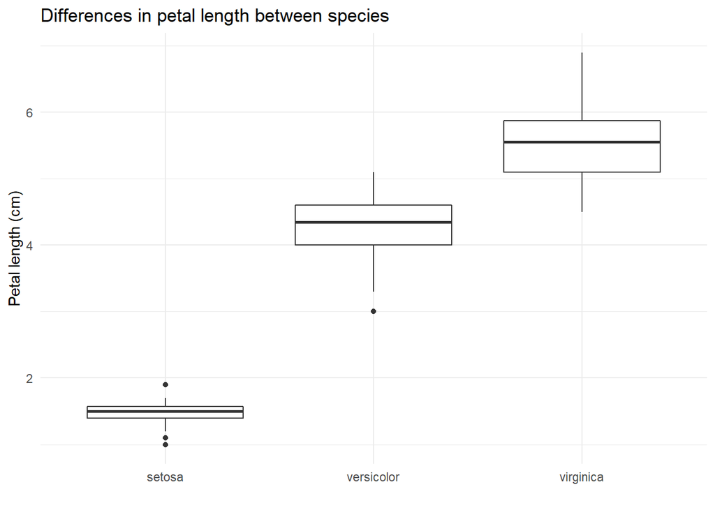

```r
iris %>%
  select(Petal.Length, Species) %>%
  ggplot(aes(Species, Petal.Length)) + # add `fill =` to add color to boxes
  geom_boxplot() +
  xlab("") +
  ylab("Petal length (cm)") +
  ggtitle("Differences in petal length between species") +
  theme_minimal() +
  geom_blank()
```

Use summary statistics to describe the plot better!

```r
iris %>%
  select(Petal.Length, Species) %>%
  group_by(Species) %>%
  summarise(mean = mean(Petal.Length),
            median = median(Petal.Length))
```

```
## # A tibble: 3 x 3
##   Species     mean median
##   <fct>      <dbl>  <dbl>
## 1 setosa      1.46   1.5
## 2 versicolor  4.26   4.35
## 3 virginica   5.55   5.55
```

**Bonus question**: Is there a better way to visualise the data?

## 2.4 Large data

Consider the `diamonds` data.

```r
glimpse(diamonds)
```

```
## Rows: 53,940
## Columns: 10
## $ carat   <dbl> 0.23, 0.21, 0.23, 0.29, 0.31, 0.24, 0.24, 0.26, 0.22, 0.23, 0.~
## $ cut     <ord> Ideal, Premium, Good, Premium, Good, Very Good, Very Good, Ver~
## $ color   <ord> E, E, E, I, J, J, I, H, E, H, J, J, F, J, E, E, I, J, J, J, I,~
## $ clarity <ord> SI2, SI1, VS1, VS2, SI2, VVS2, VVS1, SI1, VS2, VS1, SI1, VS1, ~
## $ depth   <dbl> 61.5, 59.8, 56.9, 62.4, 63.3, 62.8, 62.3, 61.9, 65.1, 59.4, 64~
## $ table   <dbl> 55, 61, 65, 58, 58, 57, 57, 55, 61, 61, 55, 56, 61, 54, 62, 58~
## $ price   <int> 326, 326, 327, 334, 335, 336, 336, 337, 337, 338, 339, 340, 34~
## $ x       <dbl> 3.95, 3.89, 4.05, 4.20, 4.34, 3.94, 3.95, 4.07, 3.87, 4.00, 4.~
## $ y       <dbl> 3.98, 3.84, 4.07, 4.23, 4.35, 3.96, 3.98, 4.11, 3.78, 4.05, 4.~
## $ z       <dbl> 2.43, 2.31, 2.31, 2.63, 2.75, 2.48, 2.47, 2.53, 2.49, 2.39, 2.~
```

With more than 53,000 rows, using `plot()` is ill-advised.

- Don’t do it, crush your computer and life.

However since this is a large data set we may still be able to observe patterns by randomly sampling the data to achieve at least 500 samples.

and reducing columns can help: focus on the categories that you care.

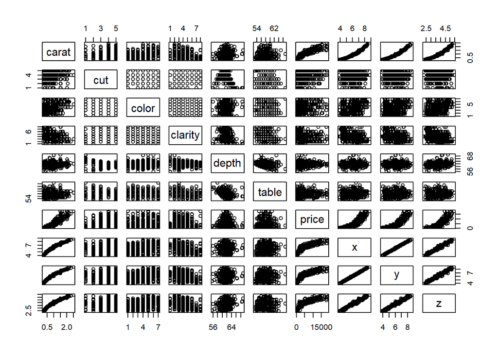

```r
diamonds %>%
  sample_frac(0.01) %>% # sample 1% of the data to plot
  plot()
```

Here we can see how `plot()` becomes less useful when many variables are involved. This is where domain knowledge comes into play. We pick variables of interest based on what we understand about diamond properties, and the quick exploratory plot that we have visualized.

From the plots, we can observe that:

- x, y, z are representing the same thing (size) because how perfect there linear relationships of each other.
- there is a possible linear relationship between carat and price.
- many variables are categorical, therefore we can explore their influence on price!

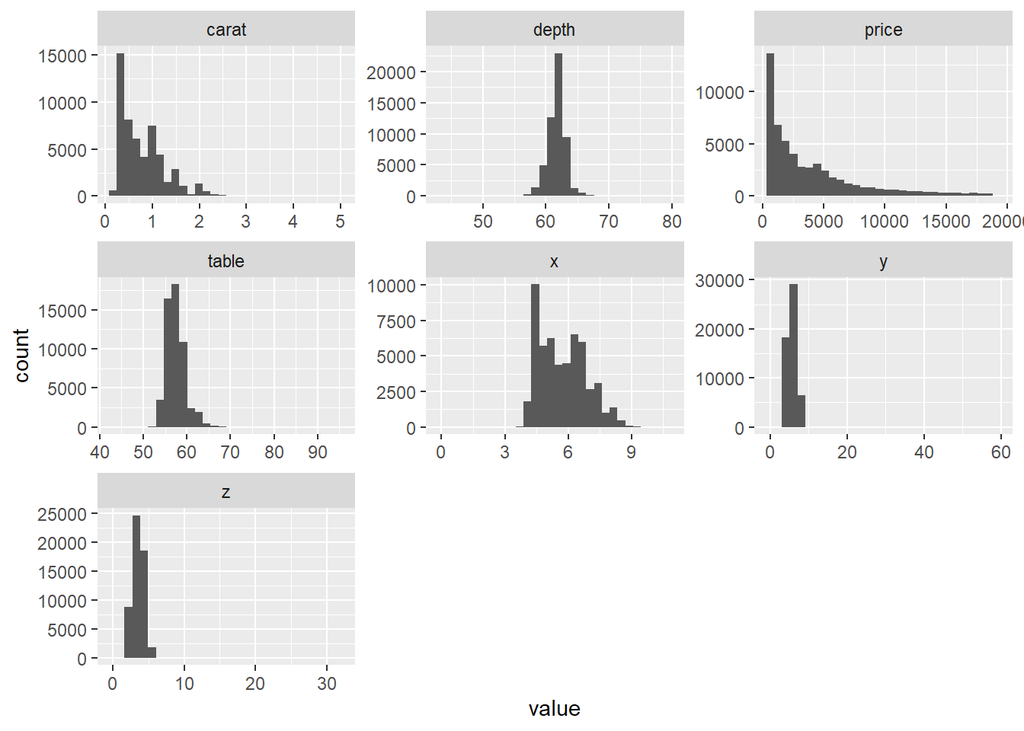

```r
diamonds %>%
  keep(is.numeric) %>%
  pivot_longer(everything()) %>% # gather all variables
  ggplot(aes(value)) +           # plot
  geom_histogram() +
  facet_wrap(~ name, scales = "free") +  # view by facet
  geom_blank()
```

Bsed on the histograms we can observe that:

- `price` is very right-skewed, which is worth investigating
- `carat` shows that high carat diamonds are rare in this dataset

> **Research question**: What is the relationship between price and carat? Is the relationship related to clarity?

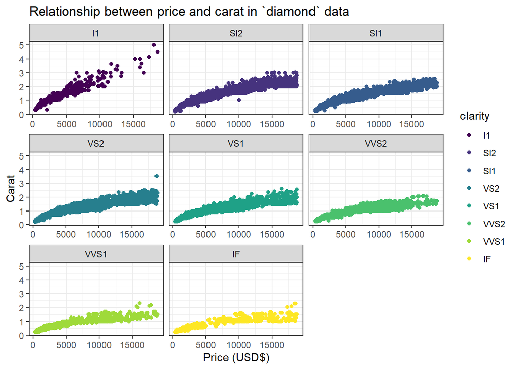

```r
diamonds %>%
  select(price, carat, clarity) %>%
  ggplot(aes(price, carat, colour = clarity)) +
  geom_point() +
  facet_wrap(~ clarity, scales = "free_x") +
  xlab("Price (USD$)") +
  ylab("Carat") +
  ggtitle("Relationship between price and carat in `diamond` data") +
  theme_bw() +
  geom_blank()
```

What are your conclusions?

> **Research question**: What is the total worth of all the diamonds in this dataset, based on colour?

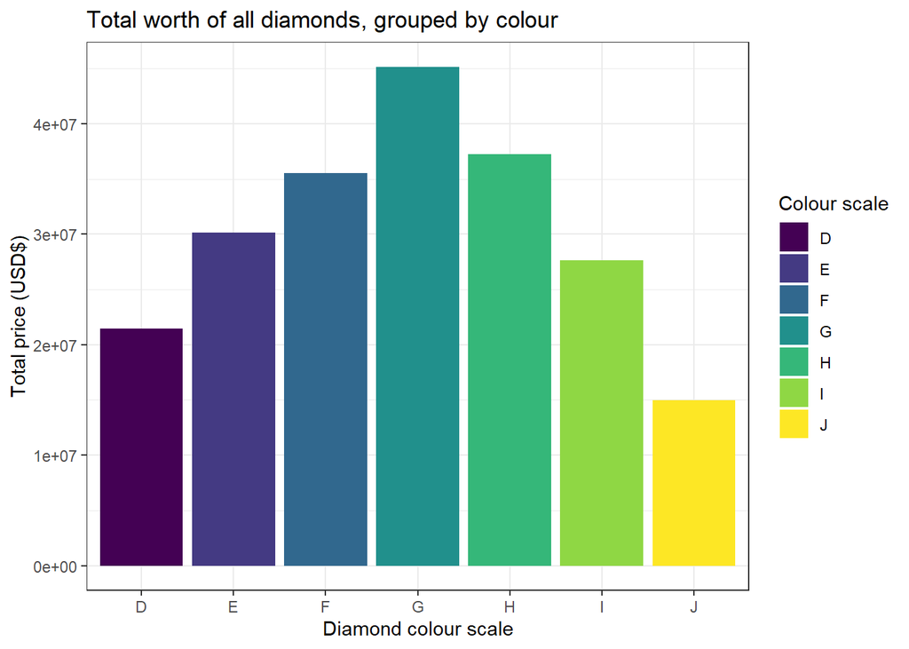

```r
diamonds %>%
  group_by(color) %>%
  summarise(total = sum(price)) %>%
  ggplot(aes(color, total)) +
  geom_bar(aes(fill = color), stat = "identity") +
  scale_colour_brewer() + # viridis
  labs(fill = "Colour scale") +
  xlab("Diamond colour scale") +
  ylab("Total price (USD$)") +
  ggtitle("Total worth of all diamonds, grouped by colour") +
  theme_bw() +
  geom_blank()
```

# 3 Explore: Texas housing data

We will use the `txhousing` data, available in `ggplot2`.

```r
glimpse(txhousing)
```

```
## Rows: 8,602
## Columns: 9
## $ city      <chr> "Abilene", "Abilene", "Abilene", "Abilene", "Abilene", "Abil~
## $ year      <int> 2000, 2000, 2000, 2000, 2000, 2000, 2000, 2000, 2000, 2000, ~
## $ month     <int> 1, 2, 3, 4, 5, 6, 7, 8, 9, 10, 11, 12, 1, 2, 3, 4, 5, 6, 7, ~
## $ sales     <dbl> 72, 98, 130, 98, 141, 156, 152, 131, 104, 101, 100, 92, 75, ~
## $ volume    <dbl> 5380000, 6505000, 9285000, 9730000, 10590000, 13910000, 1263~
## $ median    <dbl> 71400, 58700, 58100, 68600, 67300, 66900, 73500, 75000, 6450~
## $ listings  <dbl> 701, 746, 784, 785, 794, 780, 742, 765, 771, 764, 721, 658, ~
## $ inventory <dbl> 6.3, 6.6, 6.8, 6.9, 6.8, 6.6, 6.2, 6.4, 6.5, 6.6, 6.2, 5.7, ~
## $ date      <dbl> 2000.000, 2000.083, 2000.167, 2000.250, 2000.333, 2000.417, ~
```

## 3.1 Domain knowledge

What is the background to the `txhousing` data? Hint: use `?txhousing`, and consider previewing the data by plotting. **Don’t forget to downsample data that contains more than 500 samples/rows.**

## 3.2 Explore

- Investigate the structure of the data
- Find interesting observations with visualisations and numerical summaries.
- Come up with several research questions to answer using `ggplot2`. **Don’t forget to add labels and refine legends.**
- Use numerical summaries to support your findings.

## 3.3 Project 1

- How is progress?
- Finalise your research questions and refine your plots based on what you have learned in this Lab
- Record your presentations early so that someone can edit the videos (if necessary).
- Any final questions?